# Wooldridge Ch3

Brendan Peek

## Ch 3 Answers

These are my answers to the end of chapter computer exercise C1 in Chapter 3 of Introductory Econometrics 5e by Jeffrey Wooldridge.

### C1

### i)

The most likely sign for $\beta_2$ is positive because we would expect higher income to allow access to better nutrition and care which would lead to a higher birthweight which is our indicator of newborn health.

### ii

It is likely that cigs and faminc are negatively correlated because people tend to smoke less as income rises.

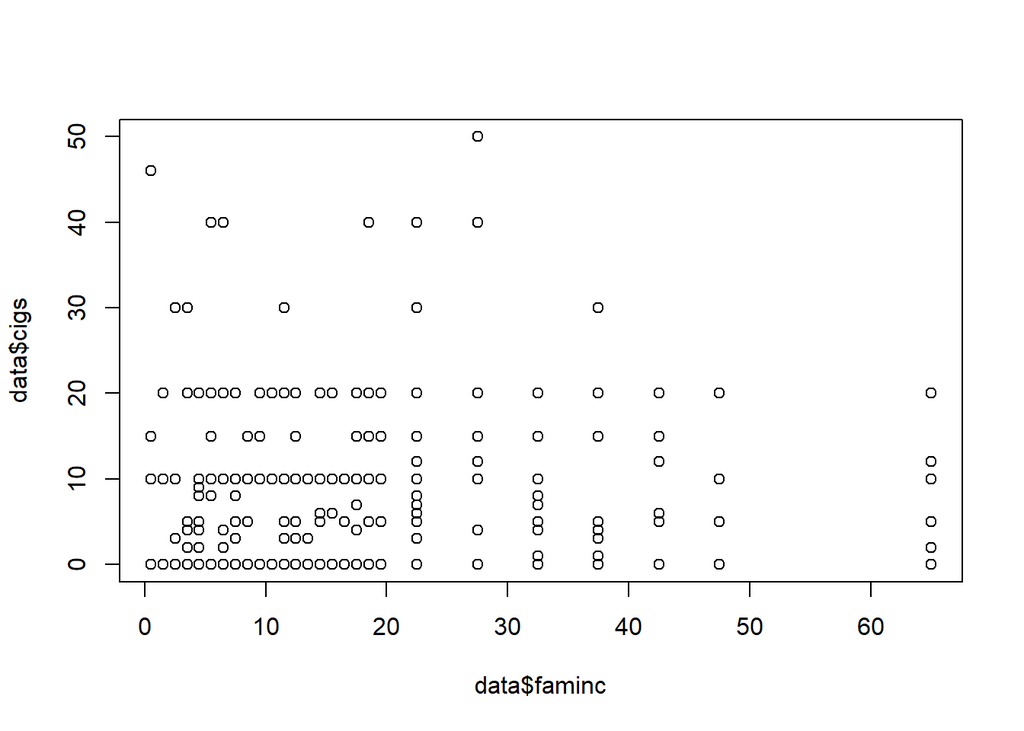

```r
plot(data$cigs ~ data$faminc)
```

```r
cor(data$cigs,data$faminc)
```

```
## [1] -0.1730449
```

There does appear to be a negative relationship between cigs and faminc in the above plot. The -0.173 correlation coefficient confirms this.

### iii)

```r
bwt.model.1 <- lm(bwght ~ cigs, data = data)
bwt.model.2 <- lm(bwght ~ cigs + faminc, data = data)
summary(bwt.model.1)
```

```
##
## Call:
## lm(formula = bwght ~ cigs, data = data)
##
## Residuals:
##     Min      1Q  Median      3Q     Max
## -96.772 -11.772   0.297  13.228 151.228
##
## Coefficients:
##              Estimate Std. Error t value Pr(>|t|)
## (Intercept) 119.77190    0.57234 209.267  < 2e-16 ***
## cigs         -0.51377    0.09049  -5.678 1.66e-08 ***
## ---
## Signif. codes:  0 '***' 0.001 '**' 0.01 '*' 0.05 '.' 0.1 ' ' 1
##
## Residual standard error: 20.13 on 1386 degrees of freedom
## Multiple R-squared:  0.02273,    Adjusted R-squared:  0.02202
## F-statistic: 32.24 on 1 and 1386 DF,  p-value: 1.662e-08
```

```r
summary(bwt.model.2)
```

```
##
## Call:
## lm(formula = bwght ~ cigs + faminc, data = data)
##
## Residuals:
##     Min      1Q  Median      3Q     Max
## -96.061 -11.543   0.638  13.126 150.083
##
## Coefficients:
##              Estimate Std. Error t value Pr(>|t|)
## (Intercept) 116.97413    1.04898 111.512  < 2e-16 ***
## cigs         -0.46341    0.09158  -5.060 4.75e-07 ***
## faminc        0.09276    0.02919   3.178  0.00151 **
## ---
## Signif. codes:  0 '***' 0.001 '**' 0.01 '*' 0.05 '.' 0.1 ' ' 1
##
## Residual standard error: 20.06 on 1385 degrees of freedom
## Multiple R-squared:  0.0298, Adjusted R-squared:  0.0284
## F-statistic: 21.27 on 2 and 1385 DF,  p-value: 7.942e-10
```

The equation without faminc is,
$$\begin{equation}
\widehat bwght = 119.8 - 0.514 * cigs \\
samplesize = 1388 \\
R^2 = 0.023
\end{equation}$$
The equation with faminc included is,
$$\begin{equation}
\widehat bwght = 116.97 - 0.463 * cigs + 0.093 * faminc \\
samplesize = 1388 \\
R^2 = 0.0298
\end{equation}$$

The difference in the coefficient on cigs between the two models is about 0.05 ounces per cigarette. Since many of the women smoked 20 cigarettes per day this could result in the estimated birthweight differing by 1 ounce between the two models. This does not seem like a significant difference in practice and indicates that cigarette smoking has a similar negative effect on birthweight regardless of access to better prenatal care.